# Assginment 1: Data types and R basics (50 poitns)

Answer keys

Fang Fang

## Load the dataset

To answer question 1-5, please load ‘adult.csv’ the into R. Note: data downloaded from [here](https://archive.ics.uci.edu/ml/datasets/Adult)

```r
library(tidyverse)
adult_income <- read_csv("data/adult.csv")
```

# Question 1. (5 points)

For this adult_income dataset, how many variables are characters?

Answer: 9 columns

# Question 2. (5 points)

The code chunk below will generate you a bar plot to display how many records we have for each education group (use the column called education). However, the factors are not ordered properly. Please reorder “education”, (Preschool < 1st-4th < 5th-6th < 7th-8th < 9th < 10th < 11th < 12th < HS-grad < Prof-school < Assoc-acdm < Assoc-voc < Some-college < Bachelors < Masters < Doctorate.) and then generate an updated barplot. Please provide both your script and barplot.

Answer:

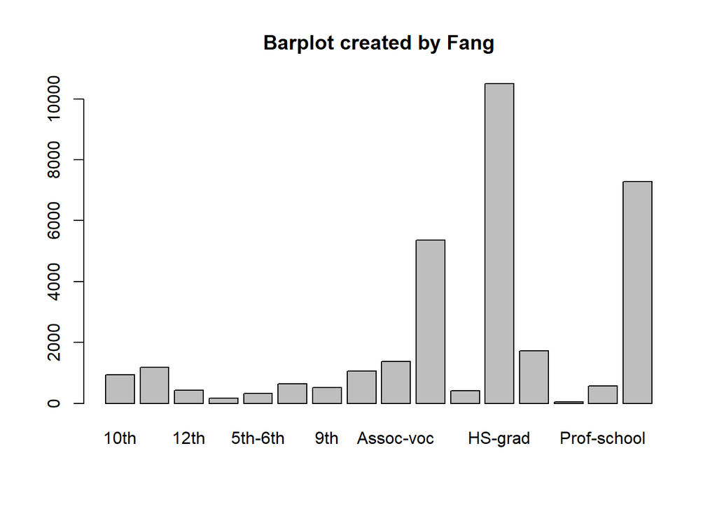

```r
barplot(table(adult_income$education), main="Barplot created by Fang")
```

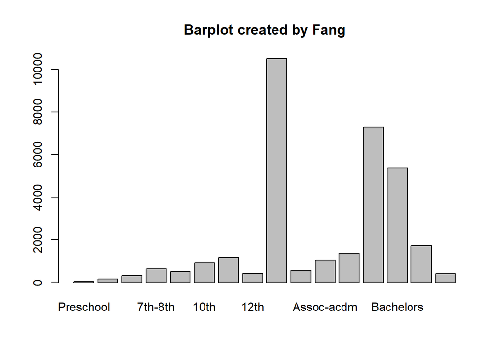

```r
adult_income$education<- factor(adult_income$education,levels =
c("Preschool" , "1st-4th", "5th-6th", "7th-8th", "9th","10th", "11th","12th", "HS-grad", "Prof-school",
  "Assoc-acdm", "Assoc-voc",  "Some-college",
  "Bachelors", "Masters", "Doctorate"))
barplot(table(adult_income$education), main="Barplot created by Fang")
```